# Reproducible Research Project 1

Ciprian Ivan

21 april 2016

Below, you will find the *R* code for extracting, transforming and summarising *activity_data*. It was a cool, instructive project.

Code for extracting “activity_data” from the url and reading into a “csv”:

```r
library("downloader");
library("dplyr");
```

```r
library("ggplot2");
require("gridExtra");
# .............. download the zip, unzip into csv .................
setwd( dir = "D:/QF/COURSERA/Reproducible Research/Project_1/" );
getwd();
```

```
## [1] "D:/QF/COURSERA/Reproducible Research/Project_1"
```

```r
download(url = "https://d396qusza40orc.cloudfront.net/repdata%2Fdata%2Factivity.zip"
         , dest = "repdata_Fdata_Factivity.zip"
         , mode="wb"
         );

unzip( zipfile = "repdata_Fdata_Factivity.zip" );
activity_data = read.csv( file = "activity.csv", sep = ",", header = TRUE );
```

*What is mean total number of steps taken per day?* * For this part of the assignment, you can ignore the missing values in the dataset. * Calculate the total number of steps taken per day * Make a histogram of the total number of steps taken each day. * Calculate and report the mean and median of the total number of steps taken per day

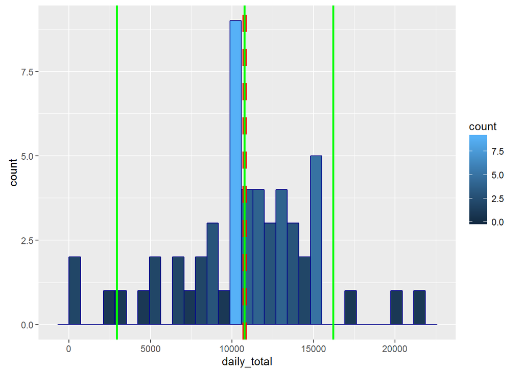

```r
df_daily = activity_data %>% group_by( date ) %>% summarise( daily_total = sum( steps ) );
# _ _ _ _ _ _ _ _ _ _ _ _  histogram _ _ _ _ _ _ _ _ _ _ _ _ _ _ _ _ _ _ _ _
ggplot( data = df_daily, aes( x = daily_total ) ) +
        geom_histogram( na.rm = TRUE , aes(fill=..count..), col = I("darkblue")  ) +
        geom_vline( aes( xintercept = mean(daily_total, na.rm = T)),
                color="red", linetype ="dashed", size = 2 ) +
        geom_vline( aes( xintercept = median(daily_total, na.rm = T)),color="green",   size = 1 ) +
        geom_vline( aes( xintercept = quantile( x = daily_total, probs = c( 0.05), na.rm = T )),color="green",   size = 1 ) +
        geom_vline( aes( xintercept = quantile( x = daily_total, probs = c( 0.95), na.rm = T )),color="green",   size = 1 )
```

```r
# _ _ _ _ _ _ _ _ _ _ _ _  mean, median _ _ _ _ _ _ _ _ _ _ _ _ _ _ _ _ _ _ _ _
mean( df_daily$daily_total, na.rm = T )
```

```
## [1] 10766.19
```

```r
median( df_daily$daily_total, na.rm = T )
```

```
## [1] 10765
```

*What is the average daily activity pattern?* * Make a time series plot (i.e. type = “l”) of the 5-minute interval (x-axis) and the average number of steps taken, averaged across all days (y-axis) * Which 5-minute interval, on average across all the days in the dataset, contains the maximum number of steps?

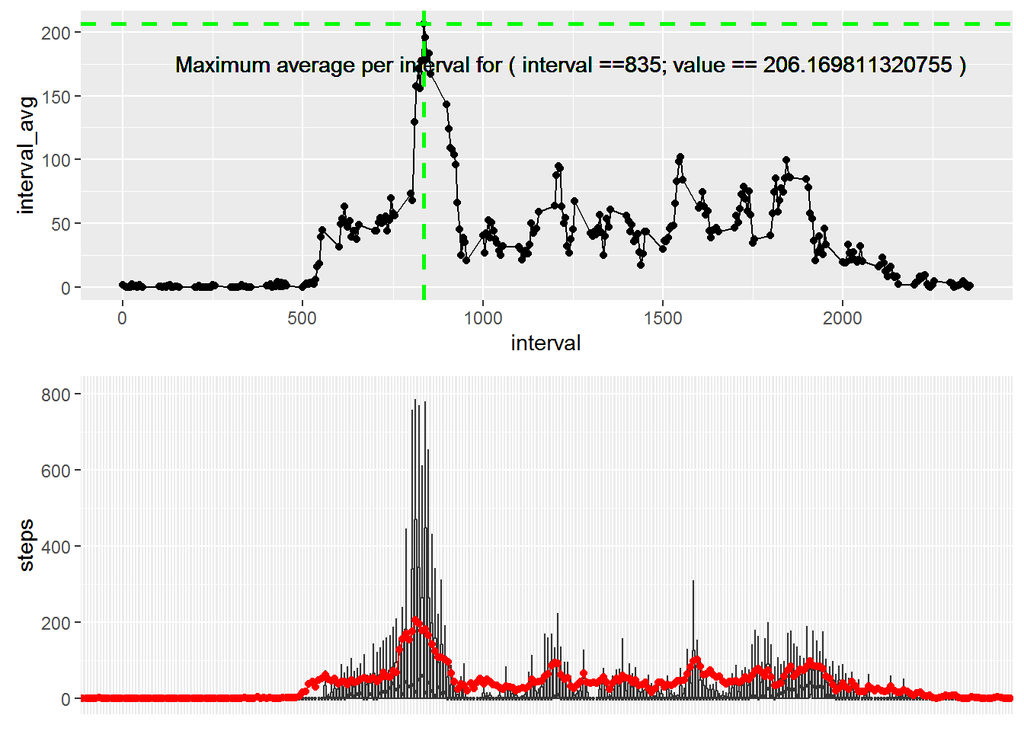

```r
# _ _ _ _ _ _ _ _ _ _ _ _ _ _ _ _ _ _
df_no_NA = activity_data %>% filter( !is.na( steps ) );
df_interval = activity_data %>% filter( !is.na( steps ) ) %>% group_by( interval ) %>% summarise( interval_avg = mean( steps ) );

df_max = df_interval [ df_interval$interval_avg == max( df_interval$interval_avg ), ];
# _ _ _ _ _ _ _ _ _ _ _ _ _ _ _ _ _ _
plot1 = ggplot( data = df_interval, aes( x = interval, y = interval_avg )) +
        geom_line(  ) +
        geom_point(  ) +
        #scale_y_continuous(limits = c(0, 800)) +
        geom_vline( aes( xintercept = df_max$interval ), color="green", size = 1, linetype = "dashed" ) +
        geom_hline( aes( yintercept = df_max$interval_avg ), color="green", size = 1, linetype = "dashed" ) +
        geom_text( data = NULL, x = df_max$interval * 1.5, y = df_max$interval_avg * 0.85,
                   label = paste0( "Maximum average per interval for ( interval ==",
                                   df_max$interval, "; value == " , df_max$interval_avg , " ) "
                                   )
                   )
# .................. geom_boxplot ...........................................
plot2 = ggplot( data = df_no_NA, aes( x = factor( interval ), y = steps ) ) +
        geom_boxplot(outlier.shape = NA) +
        theme(axis.title.x=element_blank(),
                axis.text.x=element_blank(),
                axis.ticks.x=element_blank()
              ) +
        stat_summary( fun.y = mean, geom = "line", aes( group = 1 ), colour = "red" )  +
        stat_summary( fun.y = mean, geom = "point", colour = "red" )
grid.arrange( plot1, plot2, nrow = 2 )
```

*Imputing missing values*

Note that there are a number of days/intervals where there are missing values (coded as NA). The presence of missing days may introduce bias into some calculations or summaries of the data.

- Calculate and report the total number of missing values in the dataset (i.e. the total number of rows with NAs)
- Devise a strategy for filling in all of the missing values in the dataset. The strategy does not need to be sophisticated. For example, you could use the mean/median for that day, or the mean for that 5-minute interval, etc.
- Create a new dataset that is equal to the original dataset but with the missing data filled in.
- Make a histogram of the total number of steps taken each day
- Calculate and report the mean and median total number of steps taken per day.
- Do these values differ from the estimates from the first part of the assignment?
- What is the impact of imputing missing data on the estimates of the total daily number of steps?

```r
df_NA = activity_data %>% filter( is.na( steps ) );
nrow( df_NA );
```

```
## [1] 2304
```

```r
df_NA_dist_dates = df_NA %>% distinct( date ) %>% select( date );
df_with_imputed_NAs = df_no_NA;
```

```r
#   - Create a new dataset that is equal to the original dataset but with the missing data filled in.
for (iter in 1:nrow(df_NA_dist_dates) ){
        rep_date = data.frame( rep( df_NA_dist_dates$date[ iter ], times = 288 ) );
        names( rep_date ) = "date";
        input_df = cbind.data.frame( df_interval$interval_avg,  rep_date$date,  df_interval$interval );
        names( input_df ) = c("steps", "date", "interval");
        df_with_imputed_NAs = rbind( df_with_imputed_NAs, input_df);
}
rm( list = c("rep_date", "input_df") );
df_with_imputed_NAs = df_with_imputed_NAs %>% arrange( date, interval )
```

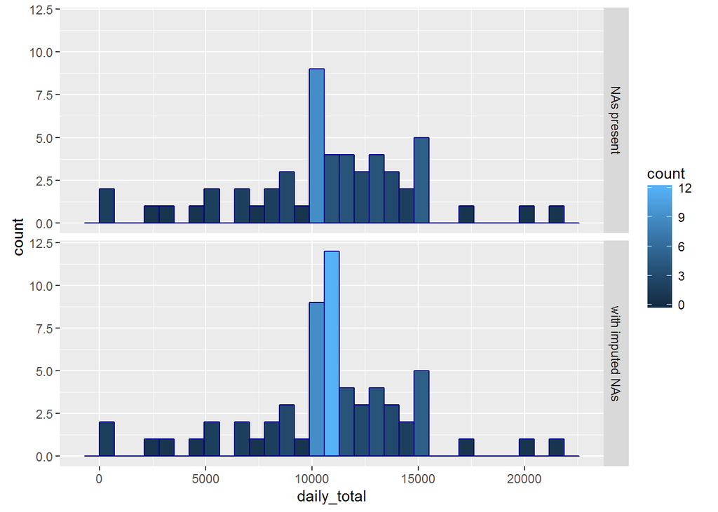

```r
#   - Make a histogram of the total number of steps taken each day
df_daily_with_imputed_NAs = df_with_imputed_NAs %>% group_by( date ) %>% summarise( daily_total = sum( steps ) );
df_daily_compare = rbind( cbind( df_daily, type = "NAs present"), cbind( df_daily_with_imputed_NAs, type = "with imputed NAs" ) );

ggplot( data = df_daily_compare, aes( x = daily_total ) ) +
        facet_grid( type ~. ) +
        geom_histogram( na.rm = TRUE , aes(fill=..count..), col = I("darkblue")  )
```

```r
# Calculate and report the mean and median total number of steps taken per day.
library(knitr);
df_synthesis_est = data.frame( mean = mean( df_daily_with_imputed_NAs$daily_total ),
                               median =median( df_daily_with_imputed_NAs$daily_total ),
                               type = "with imputed NAs");

df_synthesis_est = rbind( df_synthesis_est, data.frame( mean = mean( df_daily$daily_total, na.rm = TRUE),
                                                        median =median( df_daily$daily_total, na.rm = TRUE ),
                                                        type = "NAs present") );

kable( df_synthesis_est, format = "markdown");
```

| mean | median | type |
| --- | --- | --- |
| 10766.19 | 10766.19 | with imputed NAs |
| 10766.19 | 10765.00 | NAs present |